# WRT Internship and Photo Points

Laura Read

21-06-2022

## Waiheke Resource Trust Internship

Over Summer 2022, I volunteered as an intern for the [WRT](https://www.wrt.org.nz/). By assisting the team and their many projects, they provided me with many enriching experiences. I researched and wrote about the natural and cultural history of a wetlands site which was used in a tender document introduction. I spent time helping sort and turn compost for their Compost Co project, which reduces food waste and helps build healthy soil. I also helped welcome new residents to the island at their Ostend Market stand. However, I was always on the lookout to get involved in a GIS project!

[figure not shown]

```r
# reading and resizing image

ostend_stand <- image_read('WRT_ostend_stand.jpg') %>%
  image_scale("20%")

ostend_stand
```

## Love Our Wetlands Waiheke

[LOWW](https://www.wrt.org.nz/projects/love-our-wetlands-waiheke/) is a WRT initiative that started in 2015 and works towards the ecological restoration and protection of seven significant wetland habitats - Te Matuku, Te Whau, Matiatia headland, Rangihoua, Okahuiti, TeHuruhi Bay, and Owhanake.

The wetlands team are out Monday to Friday, visiting these sites on rotation to check and maintain plants (e.g., releasing them from weeds) and plant strategically placed and eco-sourced natives. They use ArcGIS online and the Collector app to view the current weed status of the sites, report weed infestations by dropping weed points, and log working hours per site.

## Photo Points

The WRT is working on an interactive public-facing story map using ArcGIS online to convey their wetlands mahi. I jumped at the chance to contribute to it by setting up and testing a photo points layer which will be used to show the progress of the wetland restoration. Paz, another intern, and I dropped and photographed appropriate points out in the field. The wetlands team can now update them every 3-6 months. To improve the wetlands team’s user experience, I provided insight on removing the option to drop new photo points. Ensuring the team will add photos to existing photo points instead of accidentally dropping new ones as they do with the weed points.

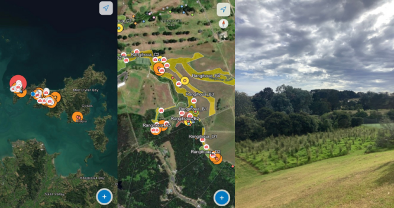

```r
# reading and resizing images
loww_map <- image_read('waiheke_loww.jpg') %>%
  image_scale("30%")

rangihoua_map <- image_read('rangihoua_loww_map.jpg') %>%
  image_scale("30%")

rangihoua_pp <- image_read('rangihoua_loww_photopoint.jpg') %>%
  image_scale("70%")

# combining and resizing images
loww_vector <- c(loww_map, rangihoua_map, rangihoua_pp)

loww <- image_append(loww_vector) %>%
  image_crop("832x440") %>%
  image_scale("80%")

loww
```

Here you can see the LOWW map (left) the wetlands team uses to update photo points (red camera icon). Then a zoomed-in image displays some of the Rangihoua polygons (centre). Finally, one of the photo point images taken at Rangihoua (right).

The story map isn’t public-facing yet however, the WRT has permitted me to display these photos.

A shout out to one of the team leaders, Maria, for taking us around Te Whau, Rangihoua, and Okahuiti all in one day to identify prime photo point spots. It significantly reduced our bushwhacking time.

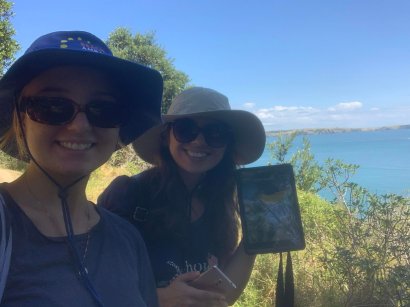

```r
# reading and resizing image

field_day <- image_read('Paz_and_I_MTIA.jpg') %>%
  image_scale("20%")

field_day
```

A photo of Paz and I dropping photo points on a beautiful day at Matiatia headlands. The photo was taken and displayed with permission.

A big thank you to the whole WRT team, especially those in the sustainability centre office who made me feel so welcome. It was fantastic to get involved with my local community and learn from the incredible change-makers on te motu. I definitely recommend other students apply for an internship at the WRT. A 10/10 experience.

This `HTML` file was created using `R Markdown` in `RStudio` using the `magick` package.

```css
@import url('https://fonts.googleapis.com/css2?family=Nanum+Gothic&family=Ultra&display=swap');

h1 {font-family: 'Ultra', serif;
    background-color: #ffffff;
    text-align: center;
    color: #3B2E1E;}

h2 {font-family: 'Ultra', serif;
        background-color: #ffffff;
        text-align: center;
        color: #4B6B3C;}

body {font-family: 'Nanum Gothic', sans-serif;
      background-color: #ffffff;
      padding: 10px;
      color: #193416;}
```